# Forecasting Inflation

Jonathan Haywood

April 10, 2022

## Introduction

In this paper, I will be creating several forecasts for inflation and comparing them to see which variables are the best predictors. I have included my code so that my results can be replicated and tested.

The models will be tested against the Philips curve specification; a model developed in 1958 which explains the inverse relationship between the unemployment rate and inflation. My “challenge” is to create a model which predicts inflation better than a model using the unemployment rate alone.

This project can also be found on my GitHub page: https://jehaywood7.github.io/

## Required R Libraries

If you want to reproduce these results these are the required packages.

```r
require(tidyverse)
require(kableExtra)
require(tidyquant)
require(lubridate)
require(timetk)
require(tsibble)
require(ggplot2)
require(reshape2)
require(fpp3)
```

## Data and Expectations

For creating the forecasts, I used monthly data obtained from the Federal Reserve Economic Data (FRED) from January 1982 up to December 2018. The models will then be tested over data from January 2019 to the most recent observation.

**Variables:**

**PCEPI**

- Personal Consumption Expenditures: Chain-type Price Index - a measure of the prices that people living in the United States pay for goods and services; used for obtaining the inflation rate.

**UNRATE**

- Unemployment Rate - number of unemployed as a percentage of the labor force; used for creating the Philips curve specification.

**EXPINF1YR**

- 1-Year Expected Inflation - the expected rate of inflation estimated by the Federal Reserve Bank of Cleveland
- This variable is estimated using a variety of economic factors such as: treasury yields, inflation data, inflation swaps, and survey-based measures of inflation expectations. So I expect this to be an excellent predictor of inflation in the economy.

**MICH**

- University of Michigan: Inflation Expectation - a survey of consumers of the median expected price change next in the next 12 months done by the University of Michigan.
- This variable functions as a judgmental forecast for inflation. While this should be a somewhat accurate predictor, it will likely be worse than EXPINF1YR because consumers often have a poor understanding of how inflation changes occur. This can be seen in the NYT article “Ordinary People Don’t Think Like Economists. It’s a Problem” which showed that many consumers don’t understand the basic relationship between the interest rate and inflation.

**HOUST**

- New Privately-Owned Housing Units Started: Total Units - new residential construction projects that begin during a certain month.
- The number of housing starts serve as an important economic indicator as it shows the quantity of homes being built so as it increases, we would expect the economy to improve as well.

```r
VarList <- c("PCEPI", "UNRATE", "EXPINF1YR", "MICH","HOUST")
infl <- tq_get(VarList, get = "economic.data", from = "1982-01-01") %>%
  mutate(Month = yearmonth(date), value = price) %>%
  select(-c(date, price)) %>%
  as_tsibble(index = Month, key = symbol)

  inflw <- infl %>%
  pivot_wider(names_from = symbol, values_from = value) %>%
  drop_na()

inflLag <- inflw %>% select(c(PCEPI, HOUST, UNRATE, EXPINF1YR, MICH)) %>%
  mutate(infl = 1200*log(PCEPI/lag(PCEPI))) %>%
  mutate(dinfl = infl - lag(infl,1)) %>%
  mutate(dinfl12 = 100*log(PCEPI/lag(PCEPI,12)) - lag(infl,12)) %>%
  mutate(unrate = UNRATE - lag(UNRATE)) %>%
  mutate(houst = 100*log(HOUST/lag(HOUST))) %>%
  mutate(expinf1yr = EXPINF1YR - lag(EXPINF1YR)) %>%
  mutate(mich = MICH - lag(MICH)) %>%
  select(-c(PCEPI, UNRATE, HOUST, EXPINF1YR, MICH)) %>%
  drop_na()

train_data <- inflLag %>% filter_index(~ "2018-12")
test_data <- inflLag %>% filter_index("2019-01" ~ .)
```

## Modeling

The specification for the Philips curve is:

$$\pi^{12}_t - \pi_{t-12} = \phi +
\beta(B)\Delta \pi_{t-12} + \gamma(B) u_{t-12} + \varepsilon_t$$
This uses 12 lags so when my model estimation will use this as well. Below I modeled the Philips curve as well as my other comparison models.

```r
fitAll <- train_data %>%
  model(
    mUnrate = TSLM(dinfl12 ~ 1 +
                lag(dinfl,12) + lag(dinfl,13) + lag(dinfl,14) +
                lag(dinfl,15) + lag(dinfl,16) + lag(dinfl,17) +
                lag(dinfl,18) + lag(dinfl,19) + lag(dinfl,20) +
                lag(dinfl,21) + lag(dinfl,22) + lag(dinfl,23) +
                lag(unrate,12) + lag(unrate,13) + lag(unrate,14) +
                lag(unrate,15) + lag(unrate,16) + lag(unrate,17) +
                lag(unrate,18) + lag(unrate,19) + lag(unrate,20) +
                lag(unrate,21) + lag(unrate,22) + lag(unrate,23)
              ),
    mHoust = TSLM(dinfl12 ~ 1 +
                lag(dinfl,12) + lag(dinfl,13) + lag(dinfl,14) +
                lag(dinfl,15) + lag(dinfl,16) + lag(dinfl,17) +
                lag(dinfl,18) + lag(dinfl,19) + lag(dinfl,20) +
                lag(dinfl,21) + lag(dinfl,22) + lag(dinfl,23) +
                lag(houst,12) + lag(houst,13) + lag(houst,14) +
                lag(houst,15) + lag(houst,16) + lag(houst,17) +
                lag(houst,18) + lag(houst,19) + lag(houst,20) +
                lag(houst,21) + lag(houst,22) + lag(houst,23)
              ),
    mExpinf = TSLM(dinfl12 ~ 1 +
                lag(dinfl,12) + lag(dinfl,13) + lag(dinfl,14) +
                lag(dinfl,15) + lag(dinfl,16) + lag(dinfl,17) +
                lag(dinfl,18) + lag(dinfl,19) + lag(dinfl,20) +
                lag(dinfl,21) + lag(dinfl,22) + lag(dinfl,23) +
                lag(expinf1yr,12) + lag(expinf1yr,13) + lag(expinf1yr,14) +
                lag(expinf1yr,15) + lag(expinf1yr,16) + lag(expinf1yr,17) +
                lag(expinf1yr,18) + lag(expinf1yr,19) + lag(expinf1yr,20) +
                lag(expinf1yr,21) + lag(expinf1yr,22) + lag(expinf1yr,23)
              ),
    mMich = TSLM(dinfl12 ~ 1 +
                lag(dinfl,12) + lag(dinfl,13) + lag(dinfl,14) +
                lag(dinfl,15) + lag(dinfl,16) + lag(dinfl,17) +
                lag(dinfl,18) + lag(dinfl,19) + lag(dinfl,20) +
                lag(dinfl,21) + lag(dinfl,22) + lag(dinfl,23) +
                lag(mich,12) + lag(mich,13) + lag(mich,14) +
                lag(mich,15) + lag(mich,16) + lag(mich,17) +
                lag(mich,18) + lag(mich,19) + lag(mich,20) +
                lag(mich,21) + lag(mich,22) + lag(mich,23)
              ),
    )
tidy(fitAll)
```

| .model | term | estimate | std.error | statistic | p.value |
| --- | --- | --- | --- | --- | --- |
| mUnrate | (Intercept) | -0.0293239809 | 0.058511021 | -0.50117021 | 6.165393e-01 |
| mUnrate | lag(dinfl, 12) | -0.8509123978 | 0.028640369 | -29.71024613 | 1.879891e-101 |
| mUnrate | lag(dinfl, 13) | -0.8267521559 | 0.032199348 | -25.67605241 | 2.812148e-85 |
| mUnrate | lag(dinfl, 14) | -0.7688465157 | 0.036379881 | -21.13383812 | 2.876347e-66 |
| mUnrate | lag(dinfl, 15) | -0.7168557898 | 0.039367535 | -18.20931340 | 8.080289e-54 |
| mUnrate | lag(dinfl, 16) | -0.6531566978 | 0.040583765 | -16.09403888 | 6.962699e-45 |
| mUnrate | lag(dinfl, 17) | -0.5781278028 | 0.041885568 | -13.80255387 | 1.857901e-35 |
| mUnrate | lag(dinfl, 18) | -0.5062721034 | 0.042080266 | -12.03110520 | 1.682602e-28 |
| mUnrate | lag(dinfl, 19) | -0.4202272329 | 0.041285918 | -10.17846400 | 1.073496e-21 |
| mUnrate | lag(dinfl, 20) | -0.3245387834 | 0.040078610 | -8.09755585 | 7.555485e-15 |

[output cut: 90 more lines]

```r
fitAccTrain <- accuracy(fitAll) %>%
  select(c(".model", ".type", "MAPE")) %>%
  kable(format = "html", table.attr = "style='width:30%;' ") %>%
  kableExtra::kable_styling()
fitAccTrain
```

| .model | .type | MAPE |
| --- | --- | --- |
| mUnrate | Training | 195.0650 |
| mHoust | Training | 204.6392 |
| mExpinf | Training | 216.7754 |
| mMich | Training | 268.5676 |

The metric I will use to compare models is mean absolute percentage error (MAPE), with lowest values meaning best performing. The order of this table is expected; the Philips curve specification performs best, followed closely by housing starts and the Federal Reserve Bank of Cleveland’s expected inflation metric. The Michigan variable performed the worst likely due to the poor economic knowledge of the consumers who were surveyed. However, this is showing in sample accuracy, in the next step we will be checking how the models perform out of sample.

## Ensemble Model and Forecasting

I will now create an ensemble model by averaging all previous models:

$$mEnsemble = (mUnrate + mHoust + mExpinf
+ mMich)/4$$

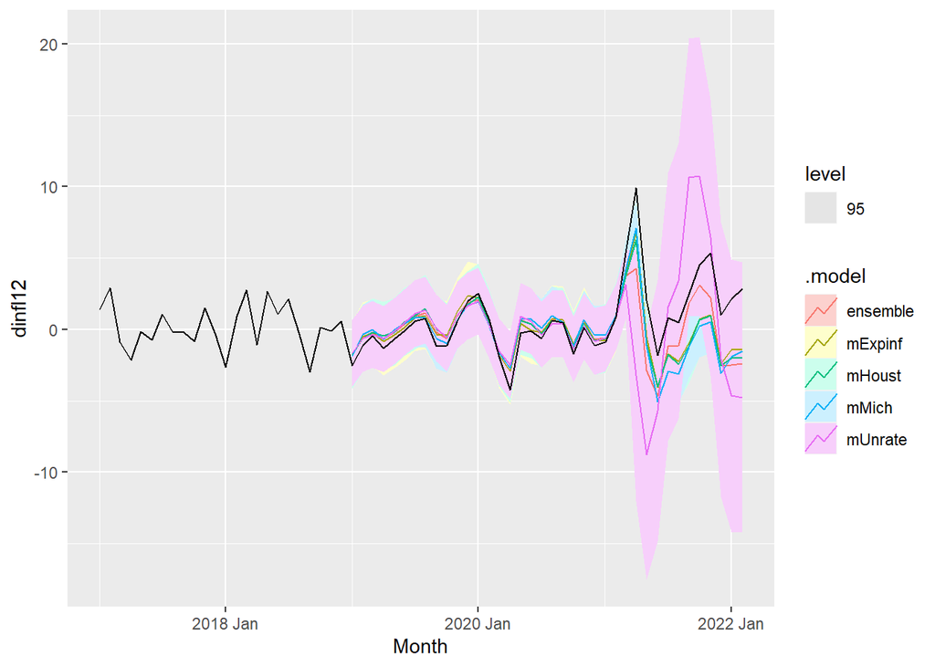

```r
fit_ensemble <- fitAll %>%
  mutate(ensemble = (mUnrate + mHoust + mExpinf + mMich)/4)
fc_ensemble <- fit_ensemble %>% forecast(new_data = test_data)
fc_ensemble %>% autoplot(filter(inflLag ,year(Month) > 2016), level = c(95))
```

```r
fit_ensemble1 <- accuracy(fit_ensemble) %>%
  select(c(".model", ".type", "MAPE")) %>%
  kable(format = "html", table.attr = "style='width:30%;' ") %>%
  kableExtra::kable_styling()
fc_ensemble1 <- accuracy(fc_ensemble, inflLag) %>%
  select(c(".model", ".type", "MAPE")) %>%
  kable(format = "html", table.attr = "style='width:30%;' ") %>%
  kableExtra::kable_styling()
```

This plot shows that our models actually performed quite well up until early 2021. This is likely due to a delayed spike in inflation caused by COVID-19; included in that was the stimulus package, which increased consumer spending rapidly.

In the training data set (from first 01/1982 to 12/2018), the ensemble model slightly beat out the Philips curve specification based on MAPE. As expected the University of Michigan model performed the worst.

| .model | .type | MAPE |
| --- | --- | --- |
| mUnrate | Training | 195.0650 |
| mHoust | Training | 204.6392 |
| mExpinf | Training | 216.7754 |
| mMich | Training | 268.5676 |
| ensemble | Training | 194.9265 |

In the test data set(from first 01/2019 to today), the model using the Federal Reserve Bank of Cleveland’s expected inflation metric outperformed all models. Interestingly, the Philips curve specification performed the worst. For forecasting, the MAPE results from the training data set are less important than the test data set as we would expect all of these models to work well in sample. This is very noticeable here as the MAPEs from the training are rather close together, and the test data set the best far out performed the worst.

| .model | .type | MAPE |
| --- | --- | --- |
| ensemble | Test | 118.6552 |
| mExpinf | Test | 105.1252 |
| mHoust | Test | 131.2759 |
| mMich | Test | 152.7666 |
| mUnrate | Test | 154.6405 |

## Conclusion

While the goal of forecasting is to give an idea of what the future could be, the presence of COVID makes forecasting anything beyond January 2020 very difficult. Even so, the model I expected to perform best at predicting future inflation, EXPINF1YR worked reasonably well out of sample. This variable uses a variety of factors to forecast inflation. From clevelandfed.org:

- Blue Chip forecast of CPI
- Inflation swap data
- CPI numbers for the current month
- CPI data from vintage FRED
- 1-month to 6-month treasury bill yield at constant maturity
- 1-year to 15-year US treasury yield: continuously compounded zero-coupon
- Survey of Professional Forecasters median year-over-year CPI inflation rate for the next 10 years

The Federal Reserve Bank of Cleveland chose the variables to model inflation, so it is no surprise that it is a strong predictor.

The ensemble model performed very well in and out of sample which is expected as it is an average of our other models and therefore controls for more variables. If I were to estimate this again, I would want to test to determine which models contribute the most to the forecasts. I believe the EXPINF1YR model should have a stronger weight and that would improve the ensemble.

## Citations

U.S. Bureau of Economic Analysis, Personal Consumption Expenditures: Chain-type Price Index [PCEPI], retrieved from FRED, Federal Reserve Bank of St. Louis; https://fred.stlouisfed.org/series/PCEPI, April 10, 2022.

U.S. Bureau of Labor Statistics, Unemployment Rate [UNRATE], retrieved from FRED, Federal Reserve Bank of St. Louis; https://fred.stlouisfed.org/series/UNRATE, April 10, 2022.

Federal Reserve Bank of Cleveland, 1-Year Expected Inflation [EXPINF1YR], retrieved from FRED, Federal Reserve Bank of St. Louis; https://fred.stlouisfed.org/series/EXPINF1YR, April 10, 2022.

University of Michigan, University of Michigan: Inflation Expectation [MICH], retrieved from FRED, Federal Reserve Bank of St. Louis; https://fred.stlouisfed.org/series/MICH, April 10, 2022.

U.S. Census Bureau and U.S. Department of Housing and Urban Development, New Privately-Owned Housing Units Started: Total Units [HOUST], retrieved from FRED, Federal Reserve Bank of St. Louis; https://fred.stlouisfed.org/series/HOUST, April 10, 2022.

Coy, P. (2022, April 6). Ordinary people don’t think like economists. it’s a problem. The New York Times. Retrieved April 10, 2022, from https://www.nytimes.com/2022/04/06/opinion/economics-public-opinion.html